# Project Report

# Project Question3:

Finding the most active buyers and sellers in the primary token network, and tracking them in other tokens. Fit a distribution for the number of unique tokens they invest in. For this question, use networks of all tokens, and see if primary token’s buyers/sellers appear in other tokens.

### Loading the Data

```r
eos_token <- read.table("~/Desktop/R/Ethereum token graphs/networkeosTX.txt", quote="\"", comment.char="", header = FALSE)
colnames(eos_token) <- c("fromnodeID", "tonodeId", "unixtime", "tokenamount")
eos_frame<-data.frame(eos_token)
head(eos_frame)
```

```
##   fromnodeID tonodeId   unixtime  tokenamount
## 1    3116916    40044 1524611245 1.158800e+19
## 2    3116917    40044 1524611245 7.400000e+18
## 3    3101799  3116918 1524611245 7.500000e+19
## 4    3091415   145709 1524611245 1.352972e+20
## 5    3116919    40190 1524611290 1.999913e+20
## 6    3098886  3116920 1524611290 2.000000e+20
```

### Data Preprocessing-Removing Outliers

In Data Preprocessing, we need to filter out all the data that has tokenAmount that is greater then total amount of Token.So, Total amount of Token = total supply * number of decimals. For eos token in etheruem, it has total supply of 10^9 and subunits of 18 decimal.

Total amount of eos_token=(10^9*10^18).

### find outliers

```r
outlierdata<-eos_frame[which (eos_frame$tokenamount > (10^27)),]
```

Total Number of Outliers:

```r
message("Total number of outliers:",length(outlierdata$tokenamount))
```

```
## Total number of outliers:13571
```

### Remove outliers

```r
datawithoutoutlier<-eos_frame[which (eos_frame$tokenamount < (10^27)),]
```

### Now fetching just the details about the buyer’s id and their frequency of transaction and storing them in a data frame.

```r
frequency_table<-table(datawithoutoutlier["tonodeId"])
freq<-as.data.frame(frequency_table)
colnames(freq)<-c("BuyerId","Frequency")
head(freq)
```

```
##   BuyerId Frequency
## 1       5    118322
## 2       6        84
## 3       7      1448
## 4       8      4105
## 5      13         1
## 6      15         4
```

```r
active_buyers<-freq[rev(order(freq$Frequency)), ]
```

### Now selecting the top 30 active buyers.

```r
top_active_buyers<-head(active_buyers,30)
```

### Calculating the count of each buyer that involves in the transcation of unique token which is in the top buyer’s list and printing that count as a vector of 30 top buyers. For this, we are using the network of all tokens by setting the working directory as the path where all the token files are located.

```r
setwd("~/Desktop/R/Ethereum token graphs");
fileNames <- Sys.glob("*.txt")
files<-list.files();

count <- vector();
increment=1;
for (bid in top_active_buyers$BuyerId) {
  counter = 0;

  for(f in files){
  df<-read.delim(f,sep=" ",header = FALSE);
  if(bid %in% df[,2]){
      counter = counter +1;
      }
  }
  count[increment]=counter;
  increment=increment+1;
}

count;
```

```
##  [1] 30  1  4  2 16 26 18  4 28 23  5  1  5  7  9  5 19 24  1 17 22 25  4
## [24] 22 24 23  9  1 24  9
```

### Plotting a linear graph of top_buyers VS No_of_tokens.

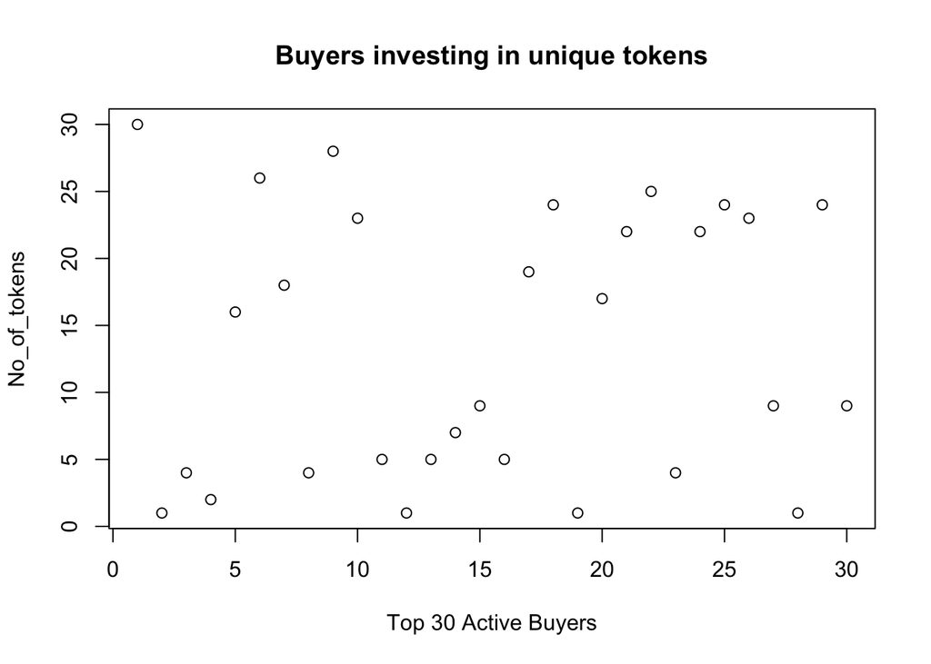

```r
x<-c(1:30);
y<-count;
plot(x,y,type = "p",xlab = "Top 30 Active Buyers",ylab = "No_of_tokens",main = "Buyers investing in unique tokens")
```

### Now fitting the distribution for the count of buyers indulged in unique tokens data.For this, we are using ‘fitdistrplus’ library.

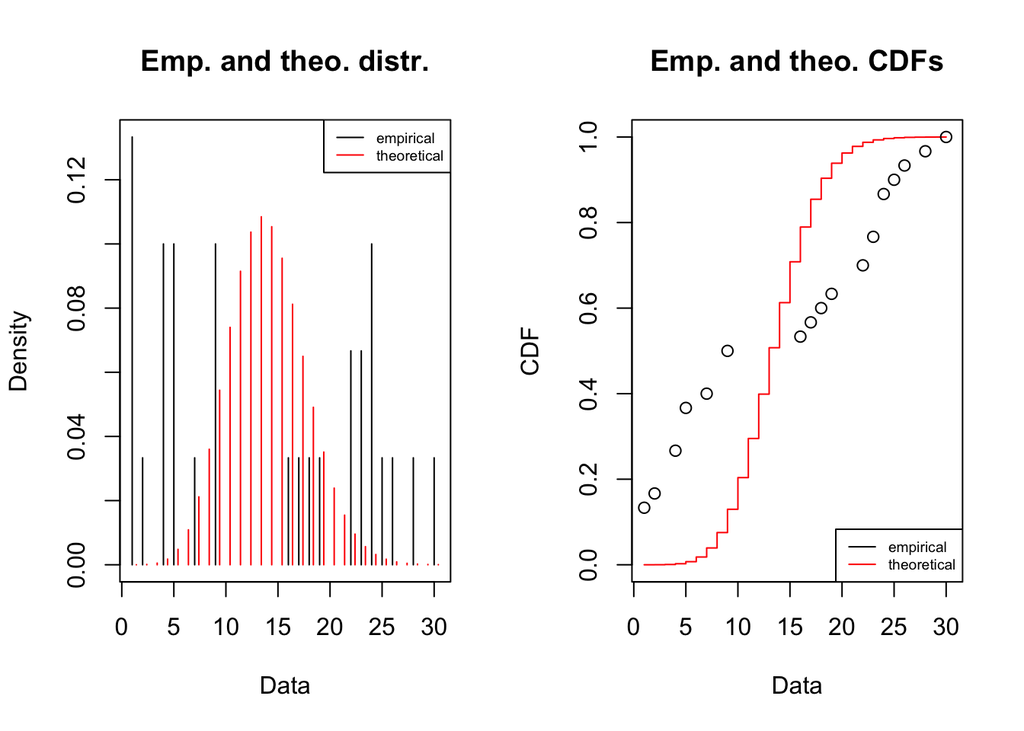

```r
library(fitdistrplus)
fit <- fitdist(count, "pois", method="mle")
plot(fit)
```

```r
summary(fit)
```

```
## Fitting of the distribution ' pois ' by maximum likelihood
## Parameters :
##        estimate Std. Error
## lambda     13.6  0.6733003
## Loglikelihood:  -180.8474   AIC:  363.6948   BIC:  365.096
```

```r
summary(count)
```

```
##    Min. 1st Qu.  Median    Mean 3rd Qu.    Max.
##    1.00    4.25   12.50   13.60   23.00   30.00
```

### Now fetching just the details about the seller’s id and their freuency of transaction and storing them in a data frame.

```r
frequency_table1<-table(datawithoutoutlier["fromnodeID"])
freq1<-as.data.frame(frequency_table1)
colnames(freq1)<-c("SellerId","Frequency")
head(freq1)
```

```
##   SellerId Frequency
## 1        5    110828
## 2        6     34171
## 3        7       360
## 4        8      7328
## 5       13     11223
## 6       15         7
```

```r
active_sellers<-freq1[rev(order(freq1$Frequency)), ]
```

### Now selecting the top 30 active sellers.

```r
top_active_sellers<-head(active_sellers,30)
```

### Calculating the count of each seller that involves in the transcation of unique token which is in the top seller’s list and printing that count as a vector of 30 top sellers. For this, we are using the network of all tokens by setting the working directory as the path where all the token files are located.

```r
setwd("~/Desktop/R/Ethereum token graphs");
fileNames <- Sys.glob("*.txt")
files<-list.files();

count1 <- vector();
increment=1;
for (sid in top_active_sellers$SellerId) {
  counter = 0;

  for(f in files){
  df<-read.delim(f,sep=" ",header = FALSE);
  if(sid %in% df[,1]){
      counter = counter +1;
      }
  }
  count1[increment]=counter;
  increment=increment+1;
}

count1
```

```
##  [1]  1 24  1  9 13 12  1  2 21  5 22 22  1 27  3 16 17  1  1  1  1 21 12
## [24] 18  4  7  3  1  6 21
```